# TheWholePat_2

Yuan

10/24/2018

## Part 1: Data preparation

```r
library(stringr)
library(plyr)
library(dplyr)
```

```r
library(ggplot2)
library(GGally)
library(CCA)
library(pheatmap)
library(plotly)
library(reshape2)
library(PMA)
library(caret)
library(Hmisc)
library(parallel)
library(knitr)
# load the functions which are writed by Cedric Huchuan Xia
source('E:\\lab\\FEP\\1011sCCA\\cca_functions.R')
```

```r
path = 'E:\\lab\\FEP\\FEP2'
```

```r
fn = 'FEP_MRI_list.csv'
filename = paste(path,fn,sep = '\\')
clin = read.csv(filename)
colnames(clin)[1] = 'ID'
rownames(clin) = clin[,1]

fn = 'FEP_fa_Feb2018.csv'
filename = paste(path,fn,sep = '\\')
fa = read.csv(filename)
colnames(fa)[1] = 'ID'
colnames(fa)[2:length(fa)] = paste("fa",colnames(fa[,c(2:length(fa))]))
rownames(fa) = fa[,1]

fn = 'FEP_MD_Feb2018.csv'  ### your data
filename = paste(path,fn,sep = '\\')
md = read.csv(filename)
colnames(md)[1] = 'ID'
colnames(md)[2:length(md)] = paste("md",colnames(md[,c(2:length(md))]))
rownames(md) = md[,1]

fn = 'FEP_fmri_Feb2018.csv'  ### your data
filename = paste(path,fn,sep = '\\')
fmri = read.csv(filename)
colnames(fmri)[1] = 'ID'
colnames(fmri)[2:length(fmri)] = paste("fmri",colnames(fmri[,c(2:length(fmri))]))
rownames(fmri) = fmri[,1]

fn = 'np.csv'
filename = paste(path,fn,sep = '\\')
np = read.csv(filename)
np = subset(np,np$visit == 'year-1')
```

```r
mt = join_all(list(clin,fa,md,fmri), by = 'ID',type = 'inner')
mt[mt == ""] = NA
mt = mt[ , apply(mt, 2, function(x) !any(is.nan(x)))]
mt = subset(mt,mt$visit == 'year-1')

mt = join_all(list(np,mt), by = 'study_ID',type = 'inner')
mt=mt[!is.na(mt$gds),]
#mt <- na.omit(mt)
mt=mt[-dim(mt)[1],] # remove FEP2068, repetitive subject
```

```r
PAT = subset(mt,group == 1) #patients
NC = subset(mt,group == 2) #controls
```

```r
fMRI_PAT=select(PAT,starts_with('fmri'))
rownames(fMRI_PAT)=PAT$study_ID

fMRI_NC=select(NC,starts_with('fmri'))
rownames(fMRI_NC)=NC$study_ID
```

```r
FS_NC=select(NC,ends_with('_Std')) # 6 Factor Score
rownames(FS_NC)=NC$study_ID
FS_PAT=select(PAT,ends_with('_Std')) # 6 Factor Score
rownames(FS_PAT)=PAT$study_ID
```

## Part 2: Do sCCA

```r
sampleid = 1:nrow(FS_PAT)

brain_sample <- mclapply(sampleid, function(id) fMRI_PAT[id,])
behavior_sample <- mclapply(sampleid, function(id) FS_PAT[id,])
```

### 2.1 select best parameters for regulariation

```r
#which(is.na(FS_PAT))#There were 2 NA in FS_PAT
#replace the NA by mean value
FS_PAT[,1] = impute(FS_PAT[,1],mean)
FS_PAT[,5] = impute(FS_PAT[,5],mean)
x_pen <- seq(0.1,1,length.out=10)
y_pen <- seq(0.1,1,length.out=10)
gs.mat <- matrix(0, nrow = 10, ncol = 10)

for (pen_xseq in x_pen) {
  pen_xseq_int = round(pen_xseq*10)
  for (pen_yseq in y_pen) {
    pen_yseq_int = round(pen_yseq*10)
    gs=ccaDW(fMRI_PAT, FS_PAT,pen_xseq,pen_yseq,6)
    gs.mat[pen_xseq_int,pen_yseq_int] = mean(abs(gs$cor))
  }
}
```

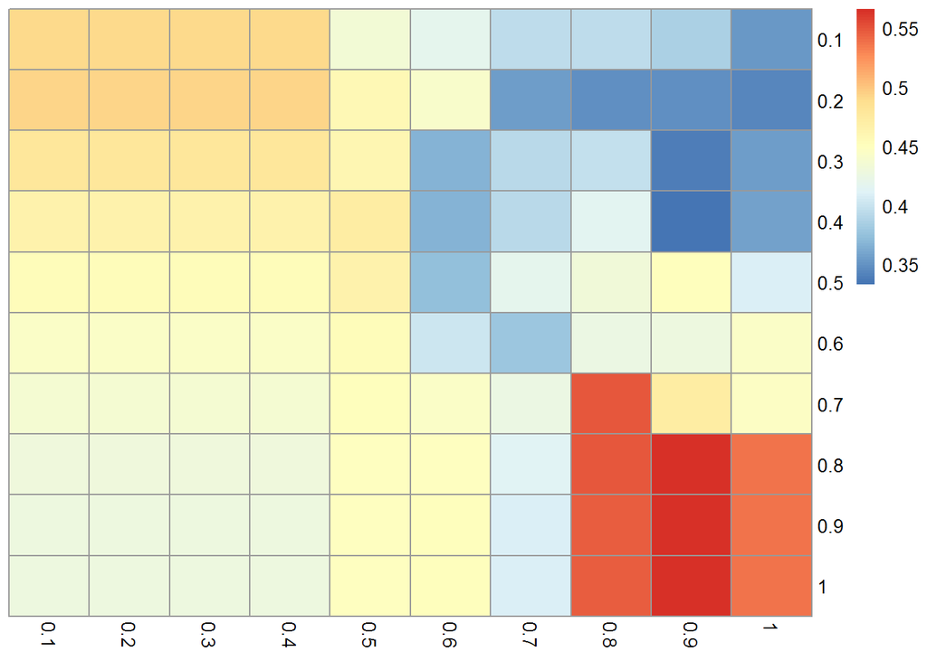

```r
rownames(gs.mat) <- x_pen
colnames(gs.mat) <- y_pen
pheatmap(gs.mat,cluster_cols = FALSE,cluster_rows = FALSE,treeheight_col = FALSE,treeheight_row = FALSE)
```

```r
which.max.matrix(gs.mat)#select the best parameters of max coralations
```

```
##      ix iy
## [1,]  8  9
```

### 2.2 select components based on covariance matrix

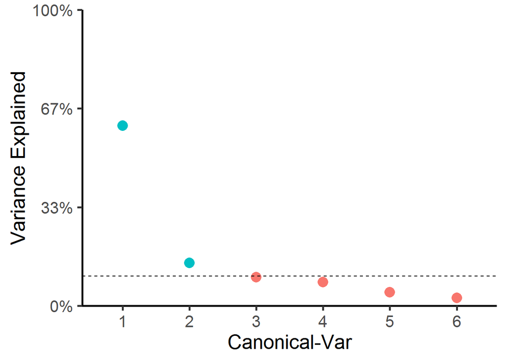

```r
modenum <- dim(FS_PAT)[2] #number of all possible canonical variates
scca.org <- ccaDW(fMRI_PAT, FS_PAT,0.8,0.9,modenum) #0.8 and 0.9 here are the best parameteres selected above in the grid search
brain_std = apply(fMRI_PAT, 2, scale)
med_std <- apply(FS_PAT,2,scale)
covmat <- t(scca.org$u) %*% t(brain_std) %*% med_std %*% scca.org$v #calculate covariance matrix
varE <- diag(covmat)^2 / sum(diag(covmat)^2) #calcualte covariance explained by each component
varE.df <- data.frame(modenum = as.factor(1:modenum), var = varE) #prepare dataframe for plotting
candnum = 6 #number selected based on the scree plot

p.var<-ggplot(varE.df,aes(modenum,var)) +
  geom_point(stat = 'identity',aes(color = var>0.1, size = 10)) +
  geom_hline(yintercept = 1/10,linetype="dashed") +
  scale_x_discrete(name ="Canonical-Var", limits=c(1:modenum),breaks =  c(1,seq(1,modenum,1))) +
  scale_y_continuous(expand = c(0, 0),limits=c(0,1),labels = scales::percent,name = "Variance Explained", breaks=seq(0,1,length=4)) +
  theme_classic(base_size = 20) +
  theme(legend.position = 'none')

p.var
```

```r
if(FALSE){
scca.cand <- ccaDW(fMRI_PAT, FS_PAT,0.8,0.9,candnum)
scca.cca<-mclapply(sampleid,function(i) ccaDW(brain_sample[[i]],behavior_sample[[i]],0.8,0.9,6)) #loop through split
scca.cca.ro <- sapply(scca.cca,function(x) reorderCCA(x,scca.cand,6)) #reorder the component so they match across splits
scca.cca.cor <- rowMeans(simplify2array(scca.cca.ro['cors',]),na.rm =T) #calculate average of cca correlations
scca.cca.cor.se <- rowSds(simplify2array(scca.cca.ro['cors',]),na.rm =T)/sqrt(dim(scca.cca.ro)[2]) #calculate standard error of correlations
}
```

### 2.3 permutation test

```r
scca.cand <- ccaDW(fMRI_PAT, FS_PAT,0.8,0.9,candnum)
num.perm <- 1000 #number of permutaitons to run
behavior.perm <- rlply(num.perm,FS_PAT[sample(nrow(FS_PAT)),]) #permute the clinical matrix by row
scca.perm.cca<-sapply(behavior.perm, function(y_perm){ out<-ccaDWpermorder(fMRI_PAT,y_perm,0.8,0.9,candnum,scca.cand)} ) #run scca again with permuted clinical but with original connectivity
perm.cor <- simplify2array(scca.perm.cca['cors',]) #extrac the correlations
perm.pval = array(0,dim = 6)
```

```r
for (f in 1:6) {
  perm.cor.cv =  perm.cor[f,]
  perm.pval[f] = length(which(perm.cor.cv>=scca.cand$cors[f]))/length(which(is.na(perm.cor.cv) == FALSE))
}
perm.pval
```

```
## [1] 0.893203883 0.679611650 0.194174757 0.271844660 0.601941748 0.009708738
```

```r
scca.org$cors
```

```
## [1] 0.2932386 0.3461521 0.6989498 0.6646745 0.6139201 0.7806979
```

```r
brain_scores = brain_std %*% scca.org$u
behavior_scores = med_std %*% scca.org$v
v = scca.org$v#cognitive factor loadings
rownames(v) = colnames(FS_PAT)
kable(v)
```

| F_Proc_Std | 0.4025114 | -0.3388170 | 0.4302507 | -0.5907082 | -0.1809505 | 0.4187919 |
| --- | --- | --- | --- | --- | --- | --- |
| F_AttMem_Std | 0.5731645 | 0.1057803 | 0.5610491 | 0.3214955 | 0.2046424 | -0.4600872 |
| F_VerbMem_Std | 0.4302619 | -0.0454385 | -0.5103920 | -0.2141715 | 0.7002414 | 0.0556300 |
| F_VisMem_Std | 0.5374986 | 0.4555429 | -0.4079890 | 0.0398877 | -0.5866385 | 0.0499537 |
| F_Ideational_Std | 0.1045787 | -0.7257914 | -0.2692539 | 0.0042684 | -0.3014739 | -0.5253730 |
| F_Executive_Std | 0.1565257 | -0.3710208 | -0.0256062 | 0.7072664 | 0.0030291 | 0.5756095 |

We can see that the first canonical variate is Memory-related  
the second canonical variate is Ideational-related  
the 6th canonical variate is IdeationalExecutive-related(which is significant through permutation test)

### 2.4 scatter plot about correlation

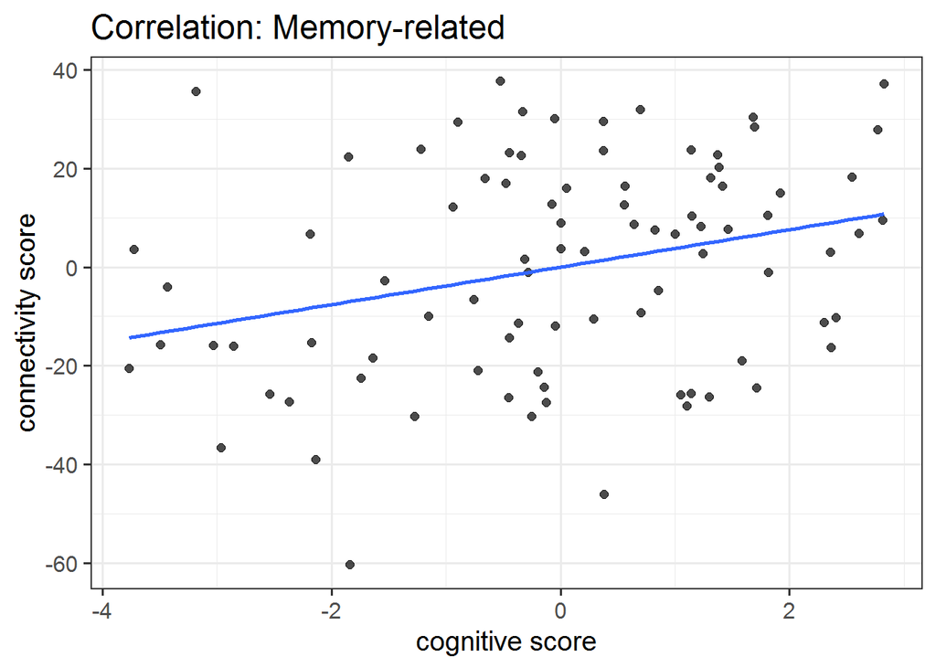

```r
df1=cbind(as.data.frame(behavior_scores[,1]),as.data.frame(brain_scores[,1]))
colnames(df1)=c('cognition','connectivity')
ggplot(df1, aes(x=cognition, y=connectivity))+
  geom_point( size = 2,alpha=0.7)+theme_bw(base_size=15)+geom_smooth(method = "lm",se = FALSE )+
  labs(x='cognitive score',y='connectivity score',title="Correlation: Memory-related")
```

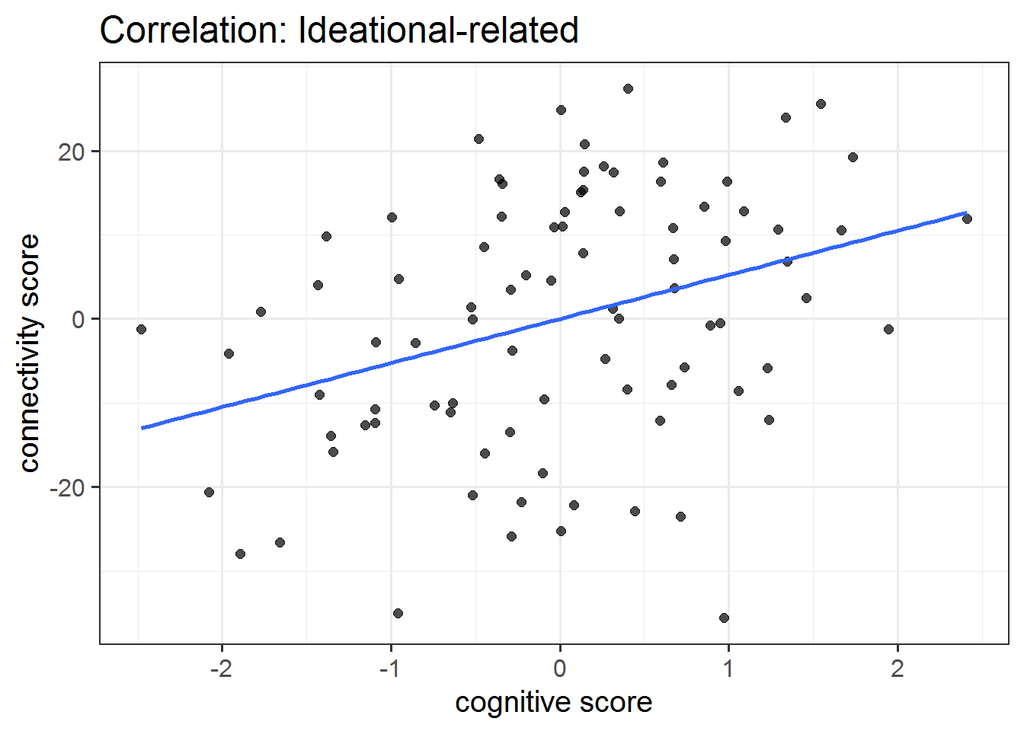

```r
df1=cbind(as.data.frame(behavior_scores[,2]),as.data.frame(brain_scores[,2]))
colnames(df1)=c('cognition','connectivity')
ggplot(df1, aes(x=cognition, y=connectivity))+
  geom_point( size = 2,alpha=0.7)+theme_bw(base_size=15)+geom_smooth(method = "lm",se = FALSE )+
  labs(x='cognitive score',y='connectivity score',title="Correlation: Ideational-related")
```

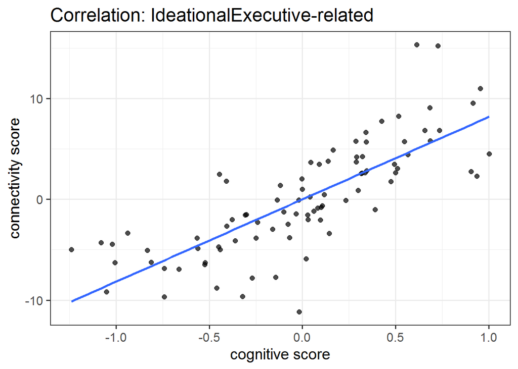

```r
df1=cbind(as.data.frame(behavior_scores[,6]),as.data.frame(brain_scores[,6]))
colnames(df1)=c('cognition','connectivity')
ggplot(df1, aes(x=cognition, y=connectivity))+
  geom_point( size = 2,alpha=0.7)+theme_bw(base_size=15)+geom_smooth(method = "lm",se = FALSE )+
  labs(x='cognitive score',y='connectivity score',title="Correlation: IdeationalExecutive-related")
```

## Part 3: Clustering

### 3.1 Hierachical clustering

```r
CV_cog = cbind(as.data.frame(behavior_scores[,1]),as.data.frame(behavior_scores[,6]))
colnames(CV_cog) = c('Memory-related','IdeationalExecutive-related')

d = dist(scale(CV_cog),method = 'euclidean')
hc = hclust(d,method = 'ward.D')
clust = cutree(hc,k = 4)
table(clust)
```

```
## clust
##  1  2  3  4
## 43 16 15 14
```

### 3.2 Heat map

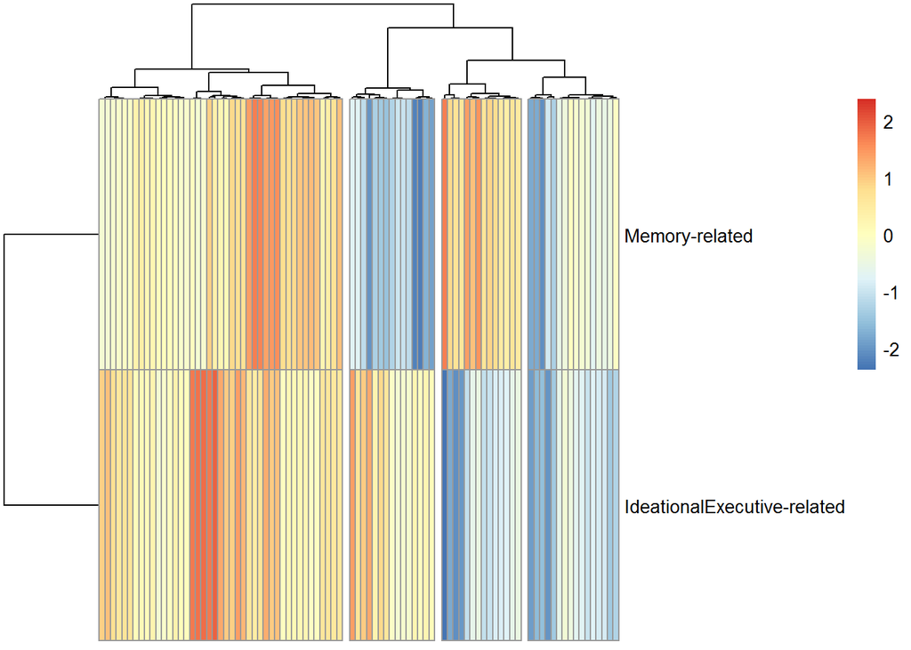

```r
clust=as.factor(clust)
PAT_whole=cbind(clust,PAT)
mat=t(as.matrix(CV_cog))
cv=data.frame('Diag'=as.factor(PAT_whole$diag2),'Cluster'=as.factor(PAT_whole$clust))
rownames(cv)=PAT_whole$study_ID
colnames(cv)=c('Diag','Cluster')
phem=pheatmap(mat,scale = 'row',annotation_col = t(cv), clustering_method="ward.D",cutree_cols=4,
              clustering_distance_cols = "euclidean",show_colnames = TRUE)
```

#### 3.3 Scatter plot

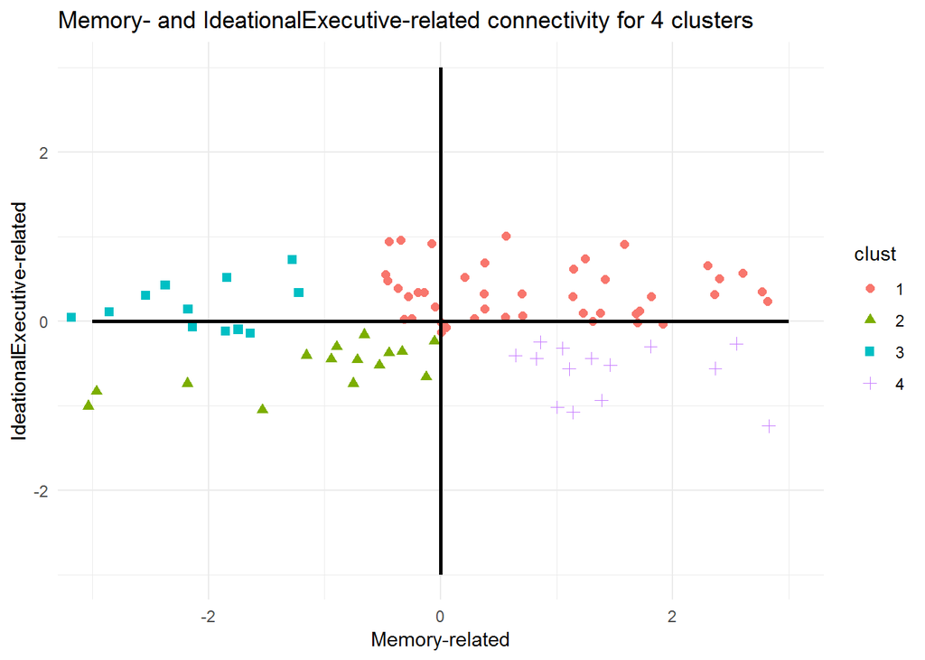

```r
CV_cog2=cbind(CV_cog,clust)
ggplot(CV_cog2, aes(x=`Memory-related`, y=`IdeationalExecutive-related`, col=clust)) +
  geom_point(aes(shape=clust), size=2)+
  coord_cartesian(xlim = c(-3,3), ylim = c(-3,3))  +
  geom_segment(x = 0,xend=0, y = -3,yend=3,size=1,col='black')+
  geom_segment(x = -3,xend=3, y = 0,yend=0,size=1,col='black')+theme_minimal()+
  labs(title='Memory- and IdeationalExecutive-related connectivity for 4 clusters')
```

#### 2.2.4 Pattern of abnormal connectivity

Calulate fisher Z-score of fmri connectivity for NC group

```r
n=nrow(fMRI_NC) #number of subjects
fMRI_labels=read.table(str_c(path,'\\fMRI_label.txt'))
q=ncol(fMRI_labels) # number of parcels for fMRI
fMRI_matrix=matrix(seq(1,q^2),ncol = q,nrow=q) # initialize 2D distance matrix for each subject
idx_lower=fMRI_matrix[lower.tri(fMRI_matrix)]
rownames(fMRI_matrix)=as.matrix(fMRI_labels)
colnames(fMRI_matrix)=as.matrix(fMRI_labels)
fMRI_array=array(0,dim=c(q,q,n)) # initialize 3D distance matrix for all subjects, the 3rd dimension corresponds to subject index
for (j in 1:n){
count=1
fMRI_matrix=matrix(0,ncol = q,nrow=q)
for (i in idx_lower) {
  fMRI_matrix[i]=fMRI_NC[j,count]
  count=count+1
}
fMRI_matrix=t(fMRI_matrix)+fMRI_matrix
fMRI_array[,,j]=fMRI_matrix
}
```

calculate the mean value of fMRI matrix in NC group(95 subjects)

```r
fMRI_matrix_mean = matrix(seq(1,q^2),ncol = q,nrow=q) # initialize 2D distance matrix
  for (j in 1:78){
    for (k in 1:78){
      fMRI_matrix_mean[j,k] = mean(fMRI_array[j,k,])
    }
  }
```

```r
fMRI_Utest_vec=vector(length = ncol(fMRI_NC)) # initialize 1D vector
for (i in 1:ncol(fMRI_NC))
{
  Utest=wilcox.test(fMRI_PAT[,i], fMRI_NC[,i])
  Umean=nrow(fMRI_NC)*nrow(fMRI_PAT)/2
  Usd=sqrt(nrow(fMRI_NC)*nrow(fMRI_PAT)*(nrow(fMRI_NC)+nrow(fMRI_PAT)+1)/12)
  Z=(Utest$statistic-Umean)/Usd
  fMRI_Utest_vec[i]=Z
}
fMRI_Utest_mat=matrix(seq(1,q^2),ncol = q,nrow=q) # initialize 2D distance matrix
idx_lower=fMRI_Utest_mat[lower.tri(fMRI_Utest_mat)]
count=1
fMRI_Utest_mat=matrix(0,ncol = q,nrow=q)
for (i in idx_lower) {
  fMRI_Utest_mat[i]=fMRI_Utest_vec[count]
  count=count+1
}
fMRI_Utest_mat=t(fMRI_Utest_mat)+fMRI_Utest_mat
```

Plot the matrix above

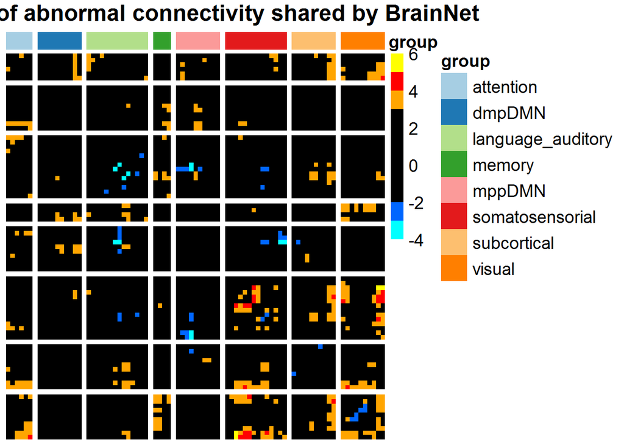

```r
fMRI_labels2=read.table(str_c(path,'\\fMRI_label2_2.txt'),stringsAsFactors=FALSE)#this file is the result of clustering percels
rownames(fMRI_Utest_mat)=as.matrix(fMRI_labels)
colnames(fMRI_Utest_mat)=as.matrix(fMRI_labels)
cv_fmri=data.frame('group'=fMRI_labels2$V1)
rownames(cv_fmri)=as.matrix(fMRI_labels)
### order the fMRI_Utest_mat by groups(BrainNet)
index <- order(cv_fmri[,1])
fMRI_Utest_mat_reorder = fMRI_Utest_mat[index,index]
fMRI_labels2_reorder = cv_fmri[index,]

col4 <- colorRampPalette(c("#00ffff","#0066ff","black","black","black","black","black","orange","red","yellow"))
#fMRI_labels2$V1=as.factor(fMRI_labels2$V1)
library(RColorBrewer)
mat_colors_fmri <- list(group = brewer.pal(length(levels(fMRI_labels2_reorder)), "Paired"))
# color palettes: http://www.datavis.ca/sasmac/brewerpal.html
# display.brewer.all() # show all color palettes
names(mat_colors_fmri$group) <- unique(fMRI_labels2_reorder)
gaps_vec=vector(length =length(unique(fMRI_labels2_reorder) )-1 )
for (i in 1:(length(unique(fMRI_labels2_reorder) )-1))
{
  gaps_vec[i]=which(fMRI_labels2_reorder==as.character(unique(fMRI_labels2_reorder)[i+1]))[1]
}


breaksList =seq(-4, 6, by = 1)


pheatmap(
  mat               = fMRI_Utest_mat_reorder,cluster_row = F, cluster_col = F,
  color             = col4(10),
  breaks=breaksList,
  border_color      = NA,
  show_colnames     = FALSE,
  show_rownames     = FALSE,
  annotation_col    = cv_fmri,
  annotation_colors = mat_colors_fmri,
  drop_levels       = TRUE,
  fontsize          = 14,
  gaps_col          = gaps_vec-1,
  gaps_row          = gaps_vec-1,
  main              = 'Pattern of abnormal connectivity shared by BrainNet'
)
```

### 3.5 Pattern of abnormal connectivity in 4 clusters(PAT group)

Here We generate a matrix showing abnormal connecivtity for each biotype. Each element is Z score of U statistic of U-test. plot Biotype 1

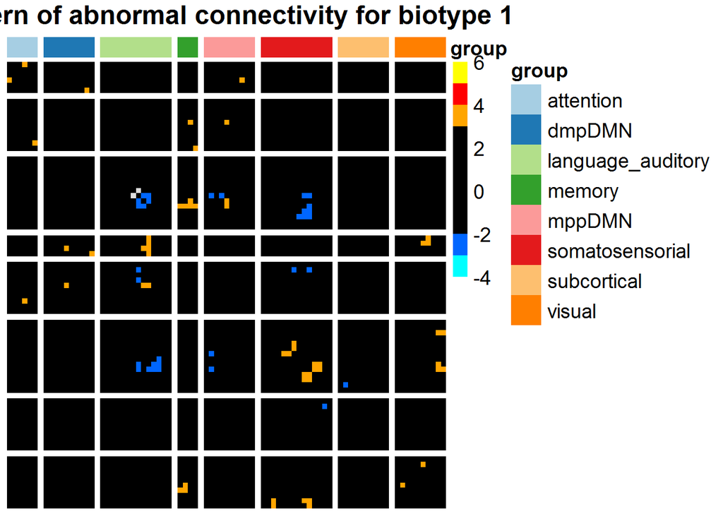

```r
PAT1=filter(PAT_whole,clust==1)
fMRI_PAT1=select(PAT1,starts_with('fmri'))
rownames(fMRI_PAT1)=PAT1$study_ID

col4 <- colorRampPalette(c("#00ffff","#0066ff","black","black","black","black","black","orange","red","yellow"))

fMRI_Utest_vec1=vector(length = ncol(fMRI_NC)) # initialize 1D vector
for (i in 1:ncol(fMRI_NC))
{
  Utest=wilcox.test(fMRI_PAT1[,i], fMRI_NC[,i])
  Umean=nrow(fMRI_NC)*nrow(fMRI_PAT1)/2
  Usd=sqrt(nrow(fMRI_NC)*nrow(fMRI_PAT1)*(nrow(fMRI_NC)+nrow(fMRI_PAT1)+1)/12)
  Z=(Utest$statistic-Umean)/Usd
  fMRI_Utest_vec1[i]=Z
}

count=1
fMRI_Utest_mat1=matrix(0,ncol = q,nrow = q)
for (i in idx_lower) {
  fMRI_Utest_mat1[i]=fMRI_Utest_vec1[count]
  count=count+1
}
fMRI_Utest_mat1=t(fMRI_Utest_mat1)+fMRI_Utest_mat1
breaksList =seq(-4, 6, by = 1)
rownames(fMRI_Utest_mat1)=as.matrix(fMRI_labels)
colnames(fMRI_Utest_mat1)=as.matrix(fMRI_labels)
fMRI_Utest_mat1_reorder = fMRI_Utest_mat1[index,index]
pheatmap(
  mat               = fMRI_Utest_mat1_reorder,cluster_row = F, cluster_col = F,
  color             = col4(10),
  breaks=breaksList,
  border_color      = NA,
  show_colnames     = FALSE,
  show_rownames     = FALSE,
  annotation_col    = cv_fmri,
  annotation_colors = mat_colors_fmri,
  drop_levels       = TRUE,
  fontsize          = 14,
  gaps_col          = gaps_vec-1,
  gaps_row          = gaps_vec-1,
  main              = 'Pattern of abnormal connectivity for biotype 1'
)
```

plot Biotype 2

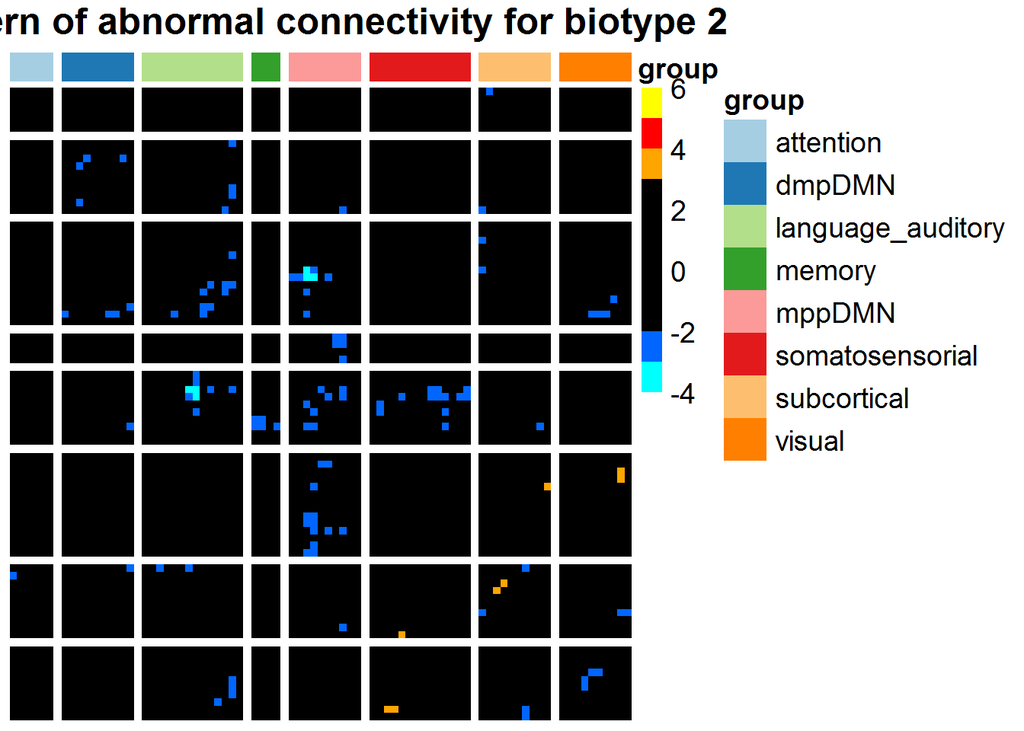

```r
PAT2=filter(PAT_whole,clust==2)
fMRI_PAT2=select(PAT2,starts_with('fmri'))
rownames(fMRI_PAT2)=PAT2$study_ID

fMRI_Utest_vec2=vector(length = ncol(fMRI_NC)) # initialize 1D vector
for (i in 1:ncol(fMRI_NC))
{
  Utest=wilcox.test(fMRI_PAT2[,i], fMRI_NC[,i])
  Umean=nrow(fMRI_NC)*nrow(fMRI_PAT2)/2
  Usd=sqrt(nrow(fMRI_NC)*nrow(fMRI_PAT2)*(nrow(fMRI_NC)+nrow(fMRI_PAT2)+1)/12)
  Z=(Utest$statistic-Umean)/Usd
  fMRI_Utest_vec2[i]=Z
}

count=1
fMRI_Utest_mat2=matrix(0,ncol = q,nrow=q)
for (i in idx_lower) {
  fMRI_Utest_mat2[i]=fMRI_Utest_vec2[count]
  count=count+1
}
fMRI_Utest_mat2=t(fMRI_Utest_mat2)+fMRI_Utest_mat2

rownames(fMRI_Utest_mat2)=as.matrix(fMRI_labels)
colnames(fMRI_Utest_mat2)=as.matrix(fMRI_labels)
fMRI_Utest_mat2_reorder = fMRI_Utest_mat2[index,index]
pheatmap(
  mat               = fMRI_Utest_mat2_reorder,cluster_row = F, cluster_col = F,
  color             = col4(10),
  breaks=breaksList,
  border_color      = NA,
  show_colnames     = FALSE,
  show_rownames     = FALSE,
  annotation_col    = cv_fmri,
  annotation_colors = mat_colors_fmri,
  drop_levels       = TRUE,
  fontsize          = 14,
  gaps_col          = gaps_vec-1,
  gaps_row          = gaps_vec-1,
  main              = 'Pattern of abnormal connectivity for biotype 2'
)
```

plot Biotype 3

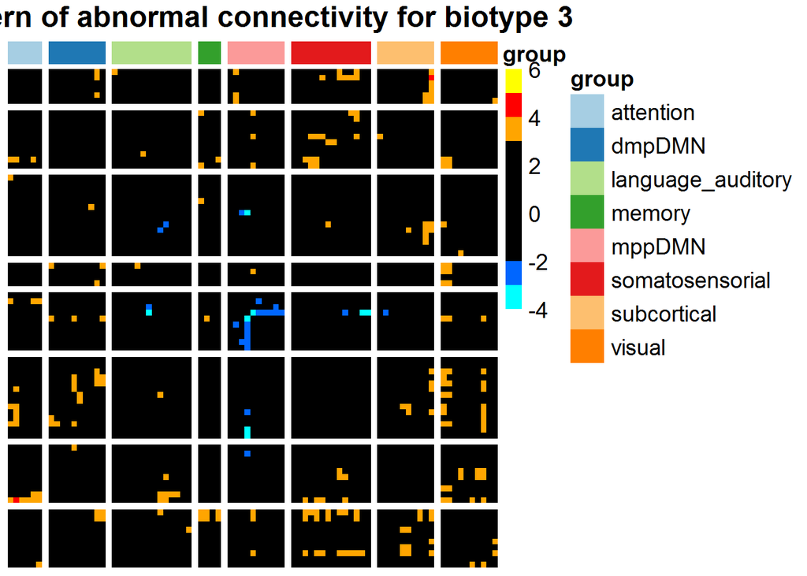

```r
PAT3=filter(PAT_whole,clust==3)
fMRI_PAT3=select(PAT3,starts_with('fmri'))
rownames(fMRI_PAT3)=PAT3$study_ID

fMRI_Utest_vec3=vector(length = ncol(fMRI_NC)) # initialize 1D vector
for (i in 1:ncol(fMRI_NC))
{
  Utest=wilcox.test(fMRI_PAT3[,i], fMRI_NC[,i])
  Umean=nrow(fMRI_NC)*nrow(fMRI_PAT3)/2
  Usd=sqrt(nrow(fMRI_NC)*nrow(fMRI_PAT3)*(nrow(fMRI_NC)+nrow(fMRI_PAT3)+1)/12)
  Z=(Utest$statistic-Umean)/Usd
  fMRI_Utest_vec3[i]=Z
}

count=1
fMRI_Utest_mat3=matrix(0,ncol = q,nrow=q)
for (i in idx_lower) {
  fMRI_Utest_mat3[i]=fMRI_Utest_vec3[count]
  count=count+1
}
fMRI_Utest_mat3=t(fMRI_Utest_mat3)+fMRI_Utest_mat3

rownames(fMRI_Utest_mat3)=as.matrix(fMRI_labels)
colnames(fMRI_Utest_mat3)=as.matrix(fMRI_labels)
fMRI_Utest_mat3_reorder = fMRI_Utest_mat3[index,index]
pheatmap(
  mat               = fMRI_Utest_mat3_reorder,cluster_row = F, cluster_col = F,
  color             = col4(10),
  breaks=breaksList,
  border_color      = NA,
  show_colnames     = FALSE,
  show_rownames     = FALSE,
  annotation_col    = cv_fmri,
  annotation_colors = mat_colors_fmri,
  drop_levels       = TRUE,
  fontsize          = 14,
  gaps_col          = gaps_vec-1,
  gaps_row          = gaps_vec-1,
  main              = 'Pattern of abnormal connectivity for biotype 3'
)
```

plot Biotype 4

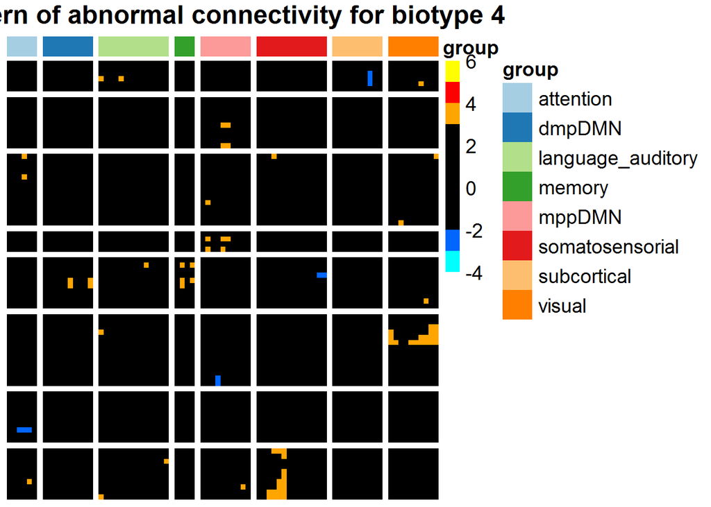

```r
PAT4=filter(PAT_whole,clust==4)
fMRI_PAT4=select(PAT4,starts_with('fmri'))
rownames(fMRI_PAT4)=PAT4$study_ID

fMRI_Utest_vec4=vector(length = ncol(fMRI_NC)) # initialize 1D vector
for (i in 1:ncol(fMRI_NC))
{
  Utest=wilcox.test(fMRI_PAT4[,i], fMRI_NC[,i])
  Umean=nrow(fMRI_NC)*nrow(fMRI_PAT4)/2
  Usd=sqrt(nrow(fMRI_NC)*nrow(fMRI_PAT4)*(nrow(fMRI_NC)+nrow(fMRI_PAT4)+1)/12)
  Z=(Utest$statistic-Umean)/Usd
  fMRI_Utest_vec4[i]=Z
}

count=1
fMRI_Utest_mat4=matrix(0,ncol = q,nrow=q)
for (i in idx_lower) {
  fMRI_Utest_mat4[i]=fMRI_Utest_vec4[count]
  count=count+1
}
fMRI_Utest_mat4=t(fMRI_Utest_mat4)+fMRI_Utest_mat4

rownames(fMRI_Utest_mat4)=as.matrix(fMRI_labels)
colnames(fMRI_Utest_mat4)=as.matrix(fMRI_labels)
fMRI_Utest_mat4_reorder = fMRI_Utest_mat4[index,index]

pheatmap(
  mat               = fMRI_Utest_mat4_reorder,cluster_row = F, cluster_col = F,
  color             = col4(10),
  breaks=breaksList,
  border_color      = NA,
  show_colnames     = FALSE,
  show_rownames     = FALSE,
  annotation_col    = cv_fmri,
  annotation_colors = mat_colors_fmri,
  drop_levels       = TRUE,
  fontsize          = 14,
  gaps_col          = gaps_vec-1,
  gaps_row          = gaps_vec-1,
  main              = 'Pattern of abnormal connectivity for biotype 4'
)
```